# path

## Serum Metabolites

https://www.metaboanalyst.ca

```python
import pandas as pd

# Load the enrichment result file
ora_df = pd.read_csv("../Pathway Enrichment/Serum Metabolites/preg/msea_ora_result.csv")

# Display the top hits
print(ora_df.head(10))
```

```
                                          Unnamed: 0  total  expected  hits  \
0    Amino acid transport across the plasma membrane     32     0.329    18
1                Amino acid transport defects (IEMs)     27     0.278    17
2                          Transcription/Translation     25     0.257    16
3    Na+/Cl- dependent neurotransmitter transporters     32     0.329    17
4  Transport of inorganic cations/anions and amin...     52     0.534    19
5                              Amino acid metabolism    109     1.120    23
6               SLC-mediated transmembrane transport    155     1.590    25
7  Transport of bile salts and organic acids, met...     76     0.781    20
8                       Transport of small molecules    208     2.140    25
9                      Cytosolic tRNA aminoacylation     66     0.678    17

          Raw p        Holm p           FDR
0  1.270000e-29  4.220000e-26  4.220000e-26
1  3.670000e-29  1.220000e-25  6.090000e-26
2  1.360000e-27  4.510000e-24  1.500000e-24
3  2.390000e-27  7.920000e-24  1.980000e-24
4  1.130000e-26  3.750000e-23  7.520000e-24
5  2.520000e-26  8.330000e-23  1.390000e-23
6  1.030000e-25  3.420000e-22  4.890000e-23
7  8.440000e-25  2.790000e-21  3.500000e-22
8  2.190000e-22  7.250000e-19  8.080000e-20
9  8.660000e-21  2.860000e-17  2.390000e-18
```

```python
# Rename the unnamed column
ora_df = ora_df.rename(columns={"Unnamed: 0": "Pathway"})

# Filter for significant pathways (FDR < 0.05)
sig_pathways = ora_df[ora_df["FDR"] < 0.05]

# View top 10 by significance
print(sig_pathways.head(10))
```

```
                                             Pathway  total  expected  hits  \
0    Amino acid transport across the plasma membrane     32     0.329    18
1                Amino acid transport defects (IEMs)     27     0.278    17
2                          Transcription/Translation     25     0.257    16
3    Na+/Cl- dependent neurotransmitter transporters     32     0.329    17
4  Transport of inorganic cations/anions and amin...     52     0.534    19
5                              Amino acid metabolism    109     1.120    23
6               SLC-mediated transmembrane transport    155     1.590    25
7  Transport of bile salts and organic acids, met...     76     0.781    20
8                       Transport of small molecules    208     2.140    25
9                      Cytosolic tRNA aminoacylation     66     0.678    17

          Raw p        Holm p           FDR
0  1.270000e-29  4.220000e-26  4.220000e-26
1  3.670000e-29  1.220000e-25  6.090000e-26
2  1.360000e-27  4.510000e-24  1.500000e-24
3  2.390000e-27  7.920000e-24  1.980000e-24
4  1.130000e-26  3.750000e-23  7.520000e-24
5  2.520000e-26  8.330000e-23  1.390000e-23
6  1.030000e-25  3.420000e-22  4.890000e-23
7  8.440000e-25  2.790000e-21  3.500000e-22
8  2.190000e-22  7.250000e-19  8.080000e-20
9  8.660000e-21  2.860000e-17  2.390000e-18
```

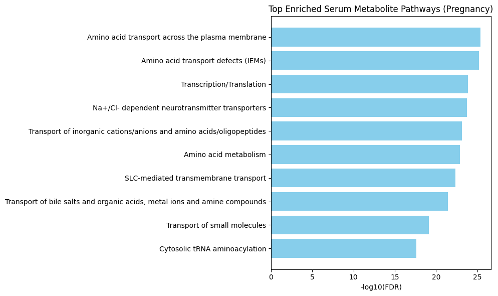

```python
import matplotlib.pyplot as plt

top_plot = sig_pathways.sort_values("FDR").head(10)

plt.figure(figsize=(10, 6))
plt.barh(top_plot["Pathway"], -np.log10(top_plot["FDR"]), color="skyblue")
plt.xlabel("-log10(FDR)")
plt.title("Top Enriched Serum Metabolite Pathways (Pregnancy)")
plt.gca().invert_yaxis()
plt.tight_layout()
plt.show()
```

```python
import pandas as pd

# Load the enrichment result file
ora_df2 = pd.read_csv("../Pathway Enrichment/Serum Metabolites/child/msea_ora_result.csv")

# Display the top hits
print(ora_df2.head(10))
```

```
                                          Unnamed: 0  total  expected  hits  \
0    Amino acid transport across the plasma membrane     32     0.314    18
1                Amino acid transport defects (IEMs)     27     0.265    17
2                          Transcription/Translation     25     0.245    16
3    Na+/Cl- dependent neurotransmitter transporters     32     0.314    17
4  Transport of inorganic cations/anions and amin...     52     0.510    19
5                              Amino acid metabolism    109     1.070    23
6               SLC-mediated transmembrane transport    155     1.520    25
7  Transport of bile salts and organic acids, met...     76     0.746    20
8                       Transport of small molecules    208     2.040    25
9                      Cytosolic tRNA aminoacylation     66     0.648    17

          Raw p        Holm p           FDR
0  4.400000e-30  1.460000e-26  1.460000e-26
1  1.370000e-29  4.540000e-26  2.270000e-26
2  5.460000e-28  1.810000e-24  6.040000e-25
3  8.930000e-28  2.960000e-24  7.400000e-25
4  3.650000e-27  1.210000e-23  2.420000e-24
5  5.810000e-27  1.920000e-23  3.210000e-24
6  1.980000e-26  6.560000e-23  9.390000e-24
7  2.520000e-25  8.350000e-22  1.050000e-22
8  4.310000e-23  1.430000e-19  1.590000e-20
9  3.280000e-21  1.090000e-17  9.080000e-19
```

```python
# Rename the unnamed column
ora_df2 = ora_df2.rename(columns={"Unnamed: 0": "Pathway"})

# Filter for significant pathways (FDR < 0.05)
sig_pathways2 = ora_df2[ora_df2["FDR"] < 0.05]

# View top 10 by significance
print(sig_pathways2.head(10))
```

```
                                             Pathway  total  expected  hits  \
0    Amino acid transport across the plasma membrane     32     0.314    18
1                Amino acid transport defects (IEMs)     27     0.265    17
2                          Transcription/Translation     25     0.245    16
3    Na+/Cl- dependent neurotransmitter transporters     32     0.314    17
4  Transport of inorganic cations/anions and amin...     52     0.510    19
5                              Amino acid metabolism    109     1.070    23
6               SLC-mediated transmembrane transport    155     1.520    25
7  Transport of bile salts and organic acids, met...     76     0.746    20
8                       Transport of small molecules    208     2.040    25
9                      Cytosolic tRNA aminoacylation     66     0.648    17

          Raw p        Holm p           FDR
0  4.400000e-30  1.460000e-26  1.460000e-26
1  1.370000e-29  4.540000e-26  2.270000e-26
2  5.460000e-28  1.810000e-24  6.040000e-25
3  8.930000e-28  2.960000e-24  7.400000e-25
4  3.650000e-27  1.210000e-23  2.420000e-24
5  5.810000e-27  1.920000e-23  3.210000e-24
6  1.980000e-26  6.560000e-23  9.390000e-24
7  2.520000e-25  8.350000e-22  1.050000e-22
8  4.310000e-23  1.430000e-19  1.590000e-20
9  3.280000e-21  1.090000e-17  9.080000e-19
```

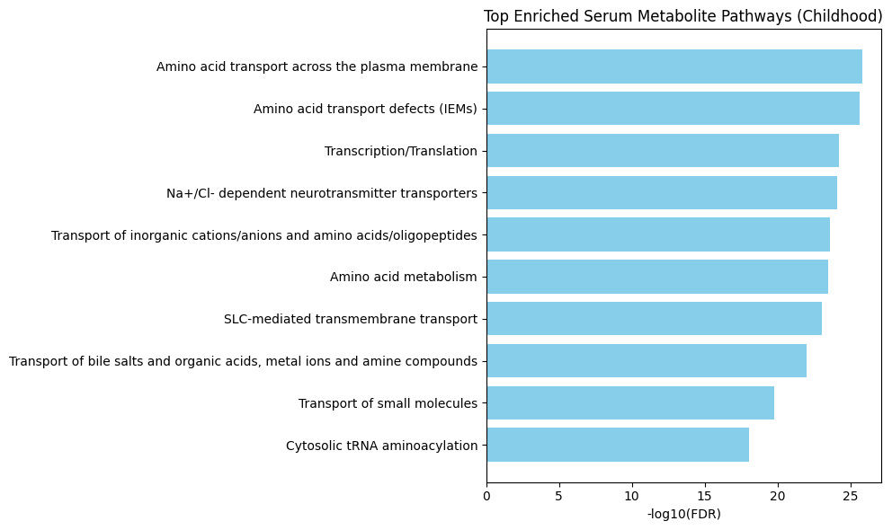

```python
import matplotlib.pyplot as plt

top_plot = sig_pathways2.sort_values("FDR").head(10)

plt.figure(figsize=(10, 6))
plt.barh(top_plot["Pathway"], -np.log10(top_plot["FDR"]), color="skyblue")
plt.xlabel("-log10(FDR)")
plt.title("Top Enriched Serum Metabolite Pathways (Childhood)")
plt.gca().invert_yaxis()
plt.tight_layout()
plt.show()
```

📄 Inference Paragraph — Serum Metabolite Pathway Enrichment To uncover biochemical mechanisms underlying exposure-associated metabolic risk, we performed pathway enrichment analysis on serum metabolites with significant risk scores derived from exposure-weighted regression models. These scores reflect how each metabolite’s abundance is influenced by environmental exposures during pregnancy and childhood, enabling us to prioritize metabolites likely to mediate early pathophysiological changes.

Metabolite Set Enrichment Analysis (MSEA) was conducted via the MetaboAnalyst platform (ORA mode) using the SMPDB compound library. For both pregnancy and childhood, the top enriched pathways included amino acid metabolism and transport, SLC-mediated transmembrane transport, neurotransmitter and bile acid transport, and tRNA aminoacylation, reflecting systemic biochemical regulation.

Notably, the top 10 pathways were nearly identical across both time points, suggesting persistent and stable disruptions in core metabolic circuits that are imprinted early and maintained through childhood. The prominence of SLC transporter pathways indicates environmentally sensitive regulation of nutrient and xenobiotic exchange, while enrichment in transcription and biosynthetic modules points to broader cellular adaptation. These findings resonate with known pathophysiological mechanisms in pediatric metabolic disorders, including impaired amino acid utilization, energy imbalance, and altered signaling.

This analysis underscores the mechanistic depth offered by serum metabolomics in exposure-health studies. By integrating MSEA-derived pathway profiles with omics-based risk scoring, we enhance the biological interpretability and translational value of our metabolic risk model.

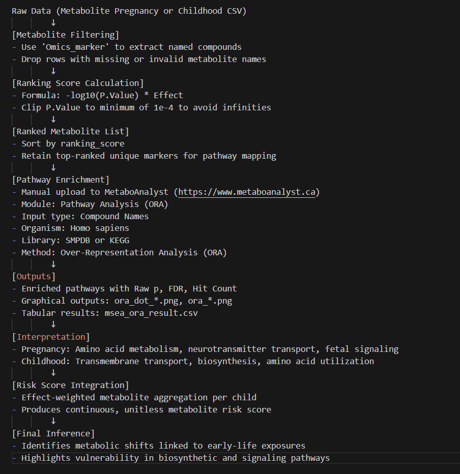